# HW 3

Mykola Chuprinskiy

2024-09-26

```
[1]   64 6830
```

```
[1] "CNS"   "CNS"   "CNS"   "RENAL"
```

```
nci.labs
     BREAST         CNS       COLON K562A-repro K562B-repro    LEUKEMIA
          7           5           7           1           1           6
MCF7A-repro MCF7D-repro    MELANOMA       NSCLC     OVARIAN    PROSTATE
          1           1           8           9           6           2
      RENAL     UNKNOWN
          9           1
```

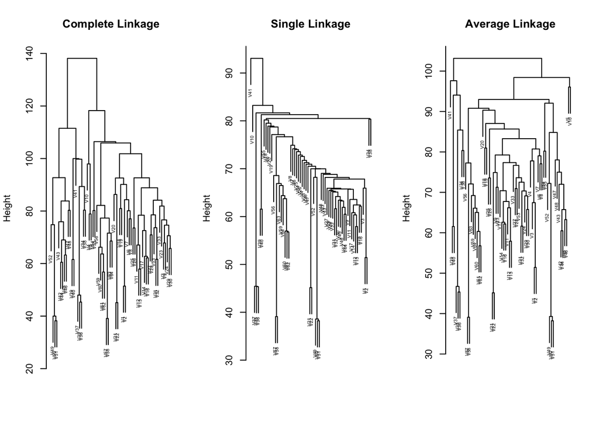

Q(a): Yes, the choice of linkage affects the clustering results. The complete linkage tends to produce more compact clusters, single linkage often results in long chains, and average linkage produces clusters that are in between the extremes of complete and single linkage. Therefore, the choice of linkage influences the shape and distribution of the clusters.

Q(b): Cell lines within a single cancer type often tend to cluster together because they share similar gene expression patterns, which results in smaller dissimilarities in the clustering.

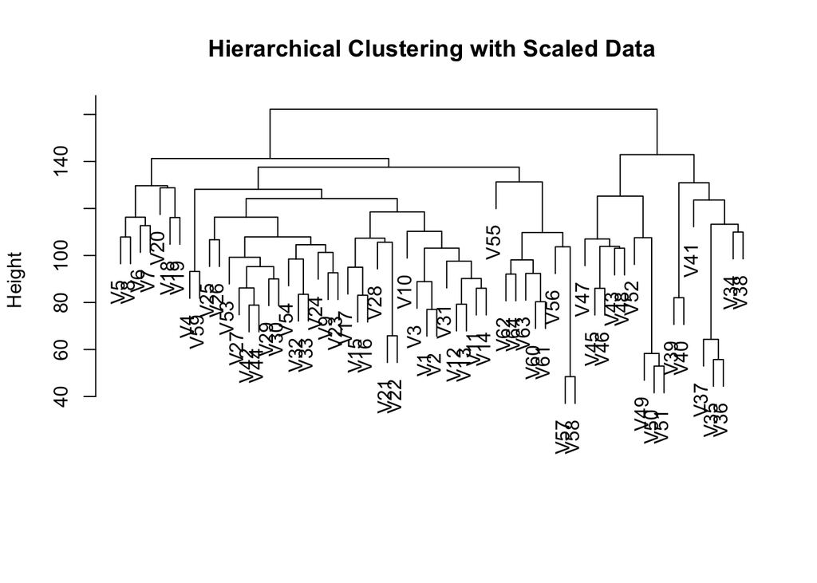

Q(c): Scaling the variables changes the influence of each gene expression measurement in the clustering. Without scaling, variables with larger variances dominate the distance calculation. Scaling ensures that each variable contributes equally, which may lead to more balanced and meaningful clusters. In most cases, scaling is advisable when variables are on different scales or have varying variances.

```
           nci.labs
hc.clusters BREAST CNS COLON K562A-repro K562B-repro LEUKEMIA MCF7A-repro
          1      2   3     2           0           0        0           0
          2      3   2     0           0           0        0           0
          3      0   0     0           1           1        6           0
          4      2   0     5           0           0        0           1
           nci.labs
hc.clusters MCF7D-repro MELANOMA NSCLC OVARIAN PROSTATE RENAL UNKNOWN
          1           0        8     8       6        2     8       1
          2           0        0     1       0        0     1       0
          3           0        0     0       0        0     0       0
          4           1        0     0       0        0     0       0
```

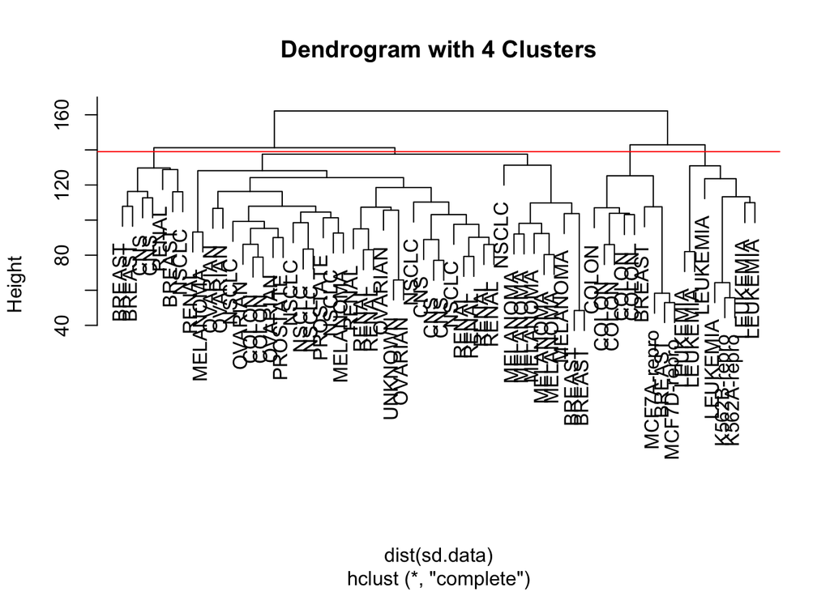

```
           hc.clusters
km.clusters  1  2  3  4
          1  0  0  8  0
          2 11  0  0  9
          3 20  7  0  0
          4  9  0  0  0
```

Q(e): The comparison between the hierarchical and K-means clustering results shows some level of agreement between the two methods. However, differences can arise because hierarchical clustering is based on the dissimilarity matrix and linkage method, while K-means relies on minimizing within-cluster variance. Therefore, the clusters identified by each method may not always align perfectly.